# xwMOOC 자동차

자동차 생산량 - 제조사별, 국가별

xwMOOC

2017-12-24

## 1. 자동차 생산량 데이터

제조사별 자동차 생산량 데이터는 현재 2017-12-24 기준 2016년 데이터만 올라와 있고, 내년 1월 초에 2017년 데이터가 올라올 것으로 기대된다. 위키백과 [List of manufacturers by motor vehicle production](https://en.wikipedia.org/wiki/List_of_manufacturers_by_motor_vehicle_production) 웹사이트에 2004 - 2016년까지 제조사별 자동차 생산량 데이터가 올라와 있으나 형태가 년도별로 상이하다.

이를 위해서 일단, 자동차 생산량 데이터를 일단 가져온다.

```r
# 0. 환경설정 ---------------
library(tidyverse)
library(rvest)
library(forcats)
library(ggpubr)
library(extrafont)
loadfonts()
library(gridExtra)
library(lubridate)
library(plotly)

# 1. 데이터 가져오기 ---------------
autowiki_webpage <- read_html("https://en.wikipedia.org/wiki/List_of_manufacturers_by_motor_vehicle_production")

html_nodes(autowiki_webpage, "table")
```

```
{xml_nodeset (15)}
 [1] <table class="wikitable sortable" style="text-align:right;">\n<tr>\ ...
 [2] <table class="wikitable sortable" style="text-align:right;">\n<tr>\ ...
 [3] <table class="wikitable sortable" style="text-align:right;">\n<tr>\ ...
 [4] <table class="wikitable sortable" style="text-align:right;">\n<tr>\ ...
 [5] <table class="wikitable sortable" style="text-align:right;">\n<tr>\ ...
 [6] <table class="toccolours nowraplinks">\n<caption><b>Top 20 motor ve ...
 [7] <table class="toccolours nowraplinks">\n<caption><b>Top 20 motor ve ...
 [8] <table class="toccolours nowraplinks">\n<caption><b>Top 20 motor ve ...
 [9] <table class="wikitable sortable" style="text-align:right;">\n<tr>\ ...
[10] <table class="wikitable sortable" style="text-align:right;">\n<tr>\ ...
[11] <table class="wikitable sortable" style="text-align:right;">\n<tr>\ ...
[12] <table class="wikitable sortable" style="text-align:right;">\n<tr>\ ...
[13] <table class="wikitable sortable" style="text-align:right;">\n<tr>\ ...
[14] <table class="nowraplinks hlist collapsible collapsed navbox-inner" ...
[15] <table class="nowraplinks navbox-subgroup" style="border-spacing:0" ...
```

```r
# 자동차 생산량 2016
vp_2016_dat <- autowiki_webpage %>%
  html_nodes("table") %>%
  .[1] %>%
  html_table(fill = TRUE) %>%
  .[[1]]

# 자동차 생산량 2015
vp_2015_dat <- autowiki_webpage %>%
  html_nodes("table") %>%
  .[2] %>%
  html_table(fill = TRUE) %>%
  .[[1]]

# 자동차 생산량 2014
vp_2014_dat <- autowiki_webpage %>%
  html_nodes("table") %>%
  .[3] %>%
  html_table(fill = TRUE) %>%
  .[[1]]

# 자동차 생산량 2013
vp_2013_dat <- autowiki_webpage %>%
  html_nodes("table") %>%
  .[4] %>%
  html_table(fill = TRUE) %>%
  .[[1]]

# 자동차 생산량 2012
vp_2012_dat <- autowiki_webpage %>%
  html_nodes("table") %>%
  .[5] %>%
  html_table(fill = TRUE) %>%
  .[[1]]

# 자동차 생산량 2011
vp_2011_dat <- autowiki_webpage %>%
  html_nodes("table") %>%
  .[6] %>%
  html_table(fill = TRUE) %>%
  .[[1]]
```

## 2. 데이터 정제

연도별 데이터 구분을 지정하고 데이터를 병합하고 웹사이트에서 데이터를 긁어오는 과정에서 발생한 오류에 대한 수정작업도 수행한다. 그리고 나서, 제조사와 국적에 대한 정제작업을 수행한다.

```r
# 2. 데이터 정제하기 ---------------
## 2.1. 연도별 데이터 합치기 -----------
## 2012 - 2016 자동차 생산량 데이터 정제
vp_2016_dat <- vp_2016_dat %>% mutate(연도 = "2016")
vp_2015_dat <- vp_2015_dat %>% mutate(연도 = "2015")
vp_2014_dat <- vp_2014_dat %>% mutate(연도 = "2014")
vp_2013_dat <- vp_2013_dat %>% mutate(연도 = "2013")
vp_2012_dat <- vp_2012_dat %>% mutate(연도 = "2012")

vp_2015_2016_dat <- bind_rows(vp_2015_dat, vp_2016_dat)
vp_2012_2014_dat <- bind_rows(vp_2012_dat, vp_2013_dat) %>%
  bind_rows(vp_2014_dat) %>%
  select(Rank, Group, Country, Vehicles = Total, 연도)

vp_2012_2016_df <- bind_rows(vp_2012_2014_dat, vp_2015_2016_dat)

## 2011년 자동차 생산량 데이터 정제
vp_2011_df <- vp_2011_dat %>% select(X1, X120) %>%
  filter(row_number() >= 4 & row_number() <= 23) %>%
  mutate(X120 = ifelse(is.na(X120), "6,616,858", X120)) %>%
  separate(X1, into=c("Rank", "Group")) %>%
  mutate(Rank = as.integer(Rank),
        연도 = "2011",
        Country = "") %>%
  select(Rank, Group, Country, Vehicles = X120, 연도)

glimpse(vp_2012_2016_df)
```

```
Observations: 100
Variables: 5
$ Rank     <int> 1, 2, 3, 4, 5, 6, 7, 8, 9, 10, 11, 12, 13, 14, 15, 16...
$ Group    <chr> "Toyota", "General Motors", "Volkswagen Group", "Hyun...
$ Country  <chr> "Japan", "United States", "Germany", "South Korea", "...
$ Vehicles <chr> "10,104,424", "9,285,425", "9,254,742", "7,126,413", ...
$ 연도     <chr> "2012", "2012", "2012", "2012", "2012", "2012", "2012",...
```

```r
## 2011 - 2016 년 자동차 생산량 데이터 정제
vp_dat <- bind_rows(vp_2011_df, vp_2012_2016_df)

## 2.2. 연도별 데이터 정제 작업 -----------

vp_df <- vp_dat %>% mutate(제조사 = case_when(
  str_detect(Group, "General") ~ "General Motors",
  str_detect(Group, "Groupe") ~ "Groupe PSA",
  str_detect(Group, "Hyundai") ~ "Hyundai / Kia",
  str_detect(Group, "Volkswagen") ~ "Volkswagen Group",
  str_detect(Group, "Dongfeng") ~ "Dongfeng Motor",
  TRUE ~ Group
))

maker_country_tbl <- vp_df %>% group_by(제조사, Country) %>%
  summarise(cnt = n()) %>%
  filter(cnt >=2) %>% select(제조사, Country)

vp_df <- left_join(vp_df, maker_country_tbl, by="제조사")

vp_df <- vp_df %>% select(연도, Rank, 제조사, 국적 = Country.y, 생산량 = Vehicles) %>%
  mutate(국적 = case_when(
    str_detect(국적, "^Italy.*States$") ~ "Italy / United States",
    str_detect(제조사, "Fiat") ~ "Italy",
    str_detect(제조사, "Chrysler") ~ "United States",
    str_detect(제조사, "Great Wall") ~ "China",
    TRUE ~ 국적)  ) %>%
  mutate(생산량 =  ifelse(str_detect(생산량, "\\("), str_extract(vp_df$Vehicles, "\\((.*?)\\)"), 생산량))

vp_df$생산량 <- map(str_extract_all(vp_df$생산량, "[0-9]+"), str_c, collapse = "") %>% unlist %>% as.integer

saveRDS(vp_df, "data_processed/vp_df.rds")
```

## 3. 시각화 및 표

### 3.1. 제조사별 생산량

연도별 각 제조사별 생산량에 대한 추세를 표를 통해 살펴본다.

```r
# 3. 자동차 생산량 시각화 -----------
## 3.1. 시각화를 위한 데이터
vp_gg_df <- vp_df %>% mutate(제조사 = case_when(
  str_detect(제조사, "Fiat|Chrysler") ~ "Fiat Chrysler",
  TRUE ~ 제조사)) %>% mutate(국가구분 = case_when(
    str_detect(국적, "India") ~ "인도",
    str_detect(국적, "China") ~ "중국",
    str_detect(국적, "France|Germany|Italy") ~ "유럽",
    str_detect(국적, "^United States") ~ "미국",
    str_detect(국적, "South Korea") ~ "한국",
    str_detect(국적, "Japan") ~ "일본",
    TRUE ~ "")) %>%
  mutate(생산량 = 생산량 / 10^6)

## 3.2. 자동차 제조사 연도별 생산량 추세
vp_gg_df %>% mutate(생산량 = 생산량 * 10^6) %>%
  select(-Rank) %>% spread(연도, 생산량) %>%
  DT::datatable() %>%
    DT::formatCurrency(c(4:10), currency="", digits=0)
```

|  | 제조사 | 국적 | 국가구분 | 2011 | 2012 | 2013 | 2014 | 2015 | 2016 |
| --- | --- | --- | --- | --- | --- | --- | --- | --- | --- |
| 1 | BAIC | China | 중국 |  |  |  | 1115847 | 1169894 | 1391643 |
| 2 | BMW | Germany | 유럽 | 1738160 | 2065477 | 2006366 | 2165566 | 2279503 | 2359756 |
| 3 | Changan | China | 중국 | 1167208 | 1063721 | 1109889 | 1447017 | 1540133 | 1715871 |
| 4 | Daimler | Germany | 유럽 | 2137067 | 2195152 | 1781507 | 1973270 | 2134645 | 2526450 |
| 5 | Dongfeng Motor | China | 중국 | 1108949 | 1137950 | 1238948 | 1301695 | 1209296 | 1315490 |
| 6 | Fiat Chrysler | Italy | 유럽 | 2336954 | 2127295 |  |  |  |  |
| 7 | Fiat Chrysler | Italy / United States | 유럽 |  |  | 4681704 | 4865758 | 4865233 | 4681457 |
| 8 | Fiat Chrysler | United States | 미국 | 1999017 | 2371427 |  |  |  |  |
| 9 | Ford | United States | 미국 | 5516931 | 5595483 | 6077126 | 5969541 | 6396369 | 6429485 |
| 10 | Geely | China | 중국 |  |  | 969896 |  |  | 1266456 |

[output cut: 14 more lines]

### 3.2. 주요 국가별 생산량 추세

중국과 인도가 자동차를 주요 국가 기간산업으로 삼아 육성하는데 심혈을 기울이고 있다. 이에 유럽, 미국, 중국, 인도, 일본, 한국을 작은 다수 창(Small Muliple) 형태로 생산량 변화를 시각적으로 살펴보자.

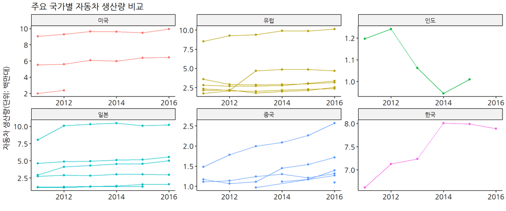

```r
## 3.3. 주요 국가별 자동차 생산량 추세
vp_gg_df %>%
  mutate(연도 = make_date(year=연도)) %>%
  ggplot(aes(x=연도, y=생산량, group=제조사, color=국가구분)) +
  geom_point() +
  geom_line() +
  facet_wrap(~국가구분, scale="free") +
  theme_pubr(base_family = "NanumGothic") +
  theme(legend.position = "none") +
  labs(x="", y="자동차 생산량(단위: 백만대)", title="주요 국가별 자동차 생산량 비교")+
  scale_x_date(limits = c(ymd("2011-01-01"), ymd("2016-01-01")))
```

### 3.2. 주요 자동차 제조사 생산량 추세

유럽과 미국, 중국, 일본, 한국 주요 제조사를 선택하여 자동차 생산량 변화 추세를 시각적으로 살펴보자.

```r
## 3.4. 주요 자동차 제조사

major_automaker <- c("BMW", "Daimler", "SAIC", "General Motors", "Honda", "Hyundai / Kia", "Toyota", "Volkswagen Group")

vp_maker_gg <- vp_gg_df %>%
  filter(제조사 %in% major_automaker) %>%
  mutate(연도 = make_date(year=연도)) %>%
  ggplot(aes(x=연도, y=생산량, group=국적, color=제조사)) +
  geom_point() +
  geom_line() +
  theme_pubr(base_family = "NanumGothic") +
  labs(x="", y="자동차 생산량(단위: 백만대)", title="주요 제조사 자동차 생산량 비교")+
  scale_x_date(limits = c(ymd("2011-01-01"), ymd("2016-01-01")))

ggplotly(vp_maker_gg)
```

[interactive chart not shown]